# Analysis of Natural Disasters and Related Losses

EPonkratova

May 21, 2016

## Synopsis

The “Analysis of Natural Disasters and Related Losses” presents a 3000 foot view on major natural disasters in the United States. It summarizes the basics of major storms and weather events i.e. rare, unusual, weather phenomena that generate media attention and other significant meteorological events that are tracked by the U.S. National Oceanic and Atmospheric Administration’s (NOAA). The original dataset by NOAA contains information on economic output (property damage) and past disaster losses (loss of life and injuries) collected between 1950 and November 2011.

## Data Processing

During the first step, the original dataset, provided as a compressed bz2 file was downloaded from the Internet.

The database cointains of 902,297 observations and 37 variables. For the purpose of this analysis, we would consider only four variables: 1. FATALITIES or number of deaths caused by natural disasters. 2. INJURIES or number of injuries caused by natural disasters. 3. PROPDMG or property damage estimated as actual dollar amounts. 4. EVTYPE i.e. storms and other significant weather phenomena, rare, unusual, weather phenomena that generate media attention, such as snow flurries in South Florida or the San Diego coastal area; and other significant meteorological events, such as record maximum or minimum temperatures or precipitation that occur in connection with another event.

Due to the different standards in data processing, it could be observed that some of Events are in upper and lower case letters. As a typeface is not recognized by R during the aggregation stage, the values in the EVNTYPE col were changed to uppercase.

```r
download.file("https://d396qusza40orc.cloudfront.net/repdata%2Fdata%2FStormData.csv.bz2", "file.csv.bz2")
original <- read.csv("file.csv.bz2", header= TRUE, nrows = 1)
str(original)
```

```
## 'data.frame':    1 obs. of  37 variables:
##  $ STATE__   : num 1
##  $ BGN_DATE  : Factor w/ 1 level "4/18/1950 0:00:00": 1
##  $ BGN_TIME  : int 130
##  $ TIME_ZONE : Factor w/ 1 level "CST": 1
##  $ COUNTY    : num 97
##  $ COUNTYNAME: Factor w/ 1 level "MOBILE": 1
##  $ STATE     : Factor w/ 1 level "AL": 1
##  $ EVTYPE    : Factor w/ 1 level "TORNADO": 1
##  $ BGN_RANGE : num 0
##  $ BGN_AZI   : logi NA
##  $ BGN_LOCATI: logi NA
##  $ END_DATE  : logi NA
##  $ END_TIME  : logi NA
##  $ COUNTY_END: num 0
```

[output cut: 23 more lines]

```r
weather <- read.csv("file.csv.bz2", header= TRUE, stringsAsFactors = FALSE)[ ,c('EVTYPE', 'FATALITIES', 'INJURIES','PROPDMG' )]
dim(weather)
```

```
## [1] 902297      4
```

```r
str(weather)
```

```
## 'data.frame':    902297 obs. of  4 variables:
##  $ EVTYPE    : chr  "TORNADO" "TORNADO" "TORNADO" "TORNADO" ...
##  $ FATALITIES: num  0 0 0 0 0 0 0 0 1 0 ...
##  $ INJURIES  : num  15 0 2 2 2 6 1 0 14 0 ...
##  $ PROPDMG   : num  25 2.5 25 2.5 2.5 2.5 2.5 2.5 25 25 ...
```

```r
library(dplyr)
weather_case <- mutate_each(weather, funs(toupper))
cols.num <- c('FATALITIES', 'INJURIES','PROPDMG');
weather_case[cols.num] <- sapply(weather_case[cols.num],as.numeric)
sapply(weather_case, class)
```

```
##      EVTYPE  FATALITIES    INJURIES     PROPDMG
## "character"   "numeric"   "numeric"   "numeric"
```

```r
str(weather_case)
```

```
## 'data.frame':    902297 obs. of  4 variables:
##  $ EVTYPE    : chr  "TORNADO" "TORNADO" "TORNADO" "TORNADO" ...
##  $ FATALITIES: num  0 0 0 0 0 0 0 0 1 0 ...
##  $ INJURIES  : num  15 0 2 2 2 6 1 0 14 0 ...
##  $ PROPDMG   : num  25 2.5 25 2.5 2.5 2.5 2.5 2.5 25 25 ...
```

## Results

In order to detect which types of events are most harmful with respect to population health? Across the United States, which types of events have the greatest economic consequences? When arranged by total number of fatalities, tornado was the most common cause of death, followed by exessive heat and flash flood. Event type | Fatalities ————- | ————- Tornado | 5,633 Excesive heat | 1903 Flash flood | 978 Heat | 937 Lighning | 816

```r
weather_aggregated <- setNames(aggregate(weather_case$FATALITIES ~ EVTYPE, data = weather_case, sum, na.rm=TRUE),c("Type", "Calc"))
sorted <- tail(weather_aggregated[order(weather_aggregated$Calc),])
aggregated_matrix <- t(sorted[-1])
colnames(aggregated_matrix) <- sorted[,1]
weather_aggregated_injuries <- setNames(aggregate(weather_case$INJURIES ~ EVTYPE, data = weather_case, sum, na.rm=TRUE),c("Type2", "Calc2"))
sorted_injuries <- tail(weather_aggregated_injuries[order(weather_aggregated_injuries$Calc2),])
aggregated_matrix_injuries <- t(sorted_injuries[-1])
colnames(aggregated_matrix_injuries) <- sorted_injuries[,1]
weather_aggregated_damage <- setNames(aggregate(weather_case$PROPDMG ~ EVTYPE, data = weather_case, sum, na.rm=TRUE),c("Type3", "Calc3"))
sorted_damage <- tail(weather_aggregated_damage[order(weather_aggregated_damage$Calc3),])
aggregated_matrix_damage <- t(sorted_damage[-1])
colnames(aggregated_matrix_damage) <- sorted_damage[,1]
sorted
```

```
##               Type Calc
## 779      TSTM WIND  504
## 418      LIGHTNING  816
## 243           HEAT  937
## 138    FLASH FLOOD  978
## 116 EXCESSIVE HEAT 1903
## 758        TORNADO 5633
```

```r
sorted_injuries
```

```
##              Type2 Calc2
## 243           HEAT  2100
## 418      LIGHTNING  5230
## 116 EXCESSIVE HEAT  6525
## 154          FLOOD  6789
## 779      TSTM WIND  6957
## 758        TORNADO 91346
```

```r
sorted_damage
```

```
##                 Type3     Calc3
## 212              HAIL  688693.4
## 685 THUNDERSTORM WIND  876844.2
## 154             FLOOD  899938.5
## 779         TSTM WIND 1335995.6
## 138       FLASH FLOOD 1420124.6
## 758           TORNADO 3212258.2
```

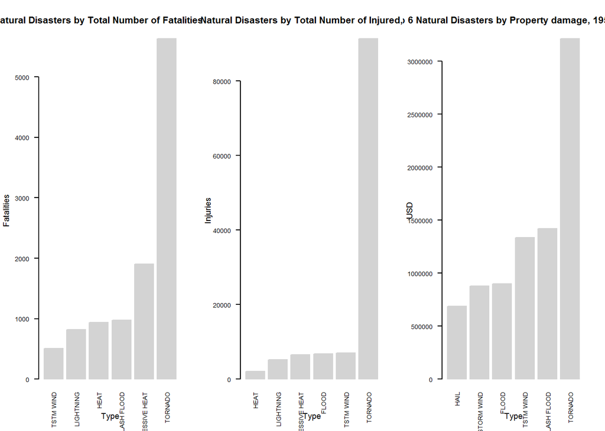

```r
par(mfrow = c(1, 3))
par(cex = 0.55)
plot1 <- barplot(aggregated_matrix, las=2, main="Top 6 Natural Disasters by Total Number of Fatalities, 1950-2011", xlab = "Type", ylab = "Fatalities", cex=0.8, cex.axis=0.8, col="lightgrey", border="lightgrey")
plot2 <- barplot(aggregated_matrix_injuries, las=2, main="Top 6 Natural Disasters by Total Number of Injured, 1950-2011", xlab = "Type", ylab = "Injuries", cex=0.8, cex.axis=0.8, col="lightgrey", border="lightgrey")
plot3 <- barplot(aggregated_matrix_damage, las=2, main="Top 6 Natural Disasters by Property damage, 1950-2011", xlab = "Type", ylab = "USD", cex=0.8, cex.axis=0.8, col="lightgrey", border="lightgrey")
```